# Air mass in solar energy

Taha Ahmed

2023-07-12

The air mass concept, as used in the solar energy research field, is a useful abstraction that encompasses:

- geometry of Earth’s curvature, which we mostly ignore except as a built-in dependence of the zenith angle with latitude (assuming we are on the date of either equinox, then at the equator the Sun reaches zenith in the skey, but at higher latitudes the solar altitude will be $90^\circ-z$ where the zenith angle $z$ equals the latitude in degrees),
- projection effect of a beam of light at a slant angle through the atmosphere which causes the beam to traverse a thickness of atmosphere depending on that angle (usually expressed in terms of the zenith angle $z$); where a beam transmitted through the atmosphere along the zenith is said to traverse “one air mass”, and a beam transmitted at a zenith angle of 60° traverses two air masses, and so on,
- the additional distance the beam is transmitted through the atmosphere (for $\mathrm{AM}>1$) also has the additional effect of increasing the scattering and absorption losses incurred before the sunlight reaches the ground, which affects the spectral composition both due to Rayleigh scattering (depends on the wavelength to the fourth power, or why the sky is blue) and due to absorption by water vapour, ozone or other molecules in the atmosphere.

The end result is that as traversed air mass increases, the total radiant power of sunlight reaching the ground decreases, and its spectral composition includes comparatively less lower-wavelength radiation. Just as air mass at noon changes with latitude, air mass for a specific location naturally also changes with time of day (see Gueymard (2012) for several examples).

At low zenith angles a good approximation is given by assuming a homogeneous plane-parallel atmosphere (i.e., one in which density is constant and Earth’s curvature is ignored). The air mass (AM) then is simply the secant of the zenith angle $z$:
$$\begin{equation}
\mathrm{AM} = \sec(z) = 1 / \cos(z)
\end{equation}$$

```r
z <- seq(0, 90, 1)
amdf <- data.frame(
   zenith = z,
   model = "PPLM",
   AM = 1 / cos(common::as.radians(z))
)
amdf <- bind_rows(
   amdf,
   data.frame(
     zenith = z,
      model = "Bemporad",
      AM = astrorefraction(z) / (common::asec2degrees(58.36) * sin(common::as.radians(z)))
   )
)
```

> To calculate the astronomical refraction $R$ (used in Bemporad’s formula) we make use of this package’s `astrorefraction()` function which internally uses values from Woolard and Clemence (1966).

As demonstrated in the following plot, using Bemporad’s formula does not gain us any meaningful improvement over the commonly used secant formula (both break down completely above around 70 degrees from the zenith). Which I guess should not be a surprise, since Bemporad’s formula depends on the astronomical refraction $R$, which function is known to become unphysical above 70°.

[figure not shown]

## Other formulas for air mass

The Bemporad formula (I’m not sure about the background of this formula, except that it is over 100 years old; Bemporad was active around the previous turn of the century), introduces a dependence on astronomical refraction $R$ (Considine and Kulik (2008)):
$$\begin{equation}
\mathrm{AM} = R / (58.36^{\prime\prime}\sin(z))
\end{equation}$$

In simplified terms, astronomical refraction is the application of [Snell’s law of refraction](https://en.wikipedia.org/wiki/Snell%27s_law) to the medium of the atmosphere, and thus gives a measure of the difference between the true zenith angle of celestial objects vs their apparent zenith angle.[^1]

The simplest models of astronomical refraction are the **concentric spherical shell model** and the **plane-parallel layer model**, with the latter being an approximation for the former (Mahan (1962)).

The secant formula for airmass (see above) follows from the plane-parallel layer model of the atmosphere when assuming constant air density and ignoring Earth’s curvature. This level of abstraction is not enough for astronomy, particularly not when the celestial object is close to the horizon. More accurate AM formulas exist (Corbard et al. (2019), Auer and Standish (2000)), but are much more work for very little or even no gain in accuracy for solar energy research purposes, in my opinion. However, it is good to keep in mind that according to such accurate formulas air mass is approximately 38 at $z\approx90^\circ$ (Sun at the horizon).

## The projection effect of air mass

AM1 occurs when the Sun is at zenith, which can only happen at noon at latitudes ±23.4° from the equator (known as the [tropic of Cancer](https://en.wikipedia.org/wiki/Tropic_of_Cancer) in the northern hemisphere and the [tropic of Capricorn](https://en.wikipedia.org/wiki/Tropic_of_Capricorn) in the southern) which is caused by Earth’s axis being tilted to the same degree.

Now imagine we were positioned on a latitude with the Sun directly overhead (so within the tropics), and started moving towards the closest pole and observing the angular distance of the Sun from zenith at noon for every new latitude. What would we see? Well, as you would expect, the *altitude* of the Sun at noon would decrease and the (complementary) angle from zenith would increase. In so doing, the distance of atmosphere traversed by the sunlight would increase (assuming the atmosphere is a plane parallel layer of constant thickness).

Note that just as air mass increases with increasing latitude, so it does with time of day. The latitude simply puts a limit on the lowest attainable air mass value at noon, but that also depends on the time of year due to Earth’s tilt.

With all that established, it becomes an exercise in simple trigonometry to calculate air mass for a given zenith angle $z$.

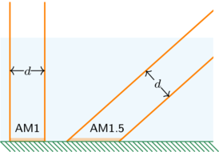

> Quick recap: AM0 is the extra-terrestrial irradiance (solar spectrum just outside earth’s atmosphere), AM1 is the terrestrial sea-level irradiance with the Sun at zenith, and AM1.5 is the irradiance with the Sun at an angle of 48.2° from the zenith. All defined for some standard values of atmospheric temperature, pressure and density[^2]

## Scattering and absorption effect of air mass

Immediately outside the atmosphere all solar irradiance is in the form of direct irradiance (meaning that all incoming irradiance is received from the direction of the Sun). The atmosphere introduces scattering and absorption, more so with increasing air mass.

Scattering introduces a diffuse component to the incoming solar irradiance. To a absorbing surface on the ground, diffuse irradiance appears to come from all directions of the sky. The sum of direct and diffuse irradiance is called *global* irradiance.

Absorption occurs by specific transition lines of the various components in the atmosphere and leads to the typical “bands” observed in the irradiance spectrum at sea level as the molecules in question are electronically excited and then usually return to their ground state via vibrational energy states.

The magnitude of attenuation of the irradiance by the atmosphere is generally given by the Beer-Lambert law, just like for a beam of light through any medium, except the absorption coefficient $\alpha$ as commonly used in chemistry is now replaced by a so-called [*optical depth* $\tau$](https://en.wikipedia.org/w/index.php?title=Optical_depth&oldid=1147496257#Atmospheric_sciences):
$$\begin{equation}
I = I_0 \exp(\tau)
\end{equation}$$
which for a slanted column can be expressed in terms of the solar zenith angle $z$ (Mueller (2012)):
$$\begin{equation}
I = I_0 \exp\left(\frac{\tau}{\cos(z)}\right)
\end{equation}$$

## Sources

- https://glossary.ametsoc.org/wiki/Bemporad's_formula
- https://en.wikipedia.org/w/index.php?title=Atmospheric_refraction&oldid=1150186905
- https://en.wikipedia.org/w/index.php?title=Air_mass_(astronomy)&oldid=1160837999
- https://en.wikipedia.org/w/index.php?title=Air_mass_(solar_energy)&oldid=1158991725
- https://en.wikipedia.org/w/index.php?title=Optical_depth&oldid=1147496257#Atmospheric_sciences

## References

Auer, Lawrence H., and E. Myles Standish. 2000. “Astronomical Refraction: Computational Method for All Zenith Angles.” *The Astronomical Journal* 119 (5): 2472. https://doi.org/10.1086/301325.

Considine, Glenn D., and Peter H. Kulik, eds. 2008. *Van Nostrand’s Scientific Encyclopedia*. 10th ed. Vol. 1–3. 3 vols. Wiley-Interscience.

Corbard, T., R. Ikhlef, F. Morand, M. Meftah, and C. Renaud. 2019. “On the Importance of Astronomical Refraction for Modern Solar Astrometric Measurements.” *Monthly Notices of the Royal Astronomical Society* 483 (3): 3865–77. https://doi.org/10.1093/mnras/sty3391.

Gueymard, Christian A. 2012. “Solar Radiation Spectrum.” In *Encyclopedia of Sustainability Science and Technology*, edited by Robert A. Meyers, 9705–30. New York, NY: Springer New York. https://doi.org/10.1007/978-1-4419-0851-3_445.

Mahan, A. I. 1962. “Astronomical Refraction–Some History and Theories.” *Applied Optics* 1 (4): 497–511. https://doi.org/10.1364/AO.1.000497.

Mueller, Richard W. 2012. “Solar Irradiance, Global Distribution.” In *Encyclopedia of Sustainability Science and Technology*, edited by Robert A. Meyers, 9619–49. New York, NY: Springer New York. https://doi.org/10.1007/978-1-4419-0851-3_447.

Woolard, Edgar W., and G. M. Clemence. 1966. *Spherical Astronomy*. Elsevier.

[^1]: A short note on terminology here: atmospheric refraction of objects far away from Earth (compared to the radius of the Earth) is termed *astronomical refraction*, and atmospheric refraction of objects close to the Earth is termed *terrestrial refraction*.
[^2]: Commonly given as a density of dry air 1.293 kg m⁻³ at a temperature of 273.15 K and a pressure of 101325 Pa under normal gravity 9.80665 m s⁻².